# 103.7. Bulk cutout stamps

For the Rubin Science Platform at data.lsst.cloud.  
Data Release: [Data Preview 2](https://dp2.lsst.io/)  
Container Size: Large  
LSST Science Pipelines version: r30.0.10  
Last verified to run: 2026-07-26  
Repository: github.com/lsst/tutorial-notebooks  
DOI: 10.11578/rubin/dc.20250909.20

**Learning objective:** How to use the Rubin image cutout service to make cutout exposures with DP2.

**LSST data products:** `deep_coadd`

**Packages:** `lsst.images`, `lsst.rsp.utils`, `pyvo`, `lsst.rsp.RSPDiscovery`, `lsst.afw.display`

**Credit:** Originally developed by the Rubin Community Science team. Please consider acknowledging them if this notebook is used for the preparation of journal articles, software releases, or other notebooks.

**Get Support:** Everyone is encouraged to ask questions or raise issues in the [Support Category](https://community.lsst.org/c/support) of the Rubin Community Forum. Rubin staff will respond to all questions posted there.

## 1. Introduction

This notebook demonstrates how to produce bulk image stamps using the Rubin cutout service, using DP2 `deep_coadd` images. Details on the Rubin cutout service can be found in the introduction of notebook tutorial 103.6 on image cutout exposures.

The cutout service performs image cutouts remotely on the server using a protocol for remote data processing operations provided by the [International Virtual Observatory Alliance (IVOA)](https://www.ivoa.net/). The [International Virtual Observatory Alliance (IVOA)](https://www.ivoa.net/) co-ordinates the community efforts of astronomical missions and archives to develop and maintain the Virtual Observatory (VO) standards. The VO standards enable interoperability between astronomical archives.

IVOA provides the [Server-side Operations for Data Access (SODA)](https://www.ivoa.net/documents/SODA/20170517/REC-SODA-1.0.html) protocol to provide these remote data processing operations. This protocol allows users to perform computations (pixel operations, image transformations, etc) on the remote server, which avoids unnecessary data movement. The LSST architecture has a "VO-first" approach, meaning that VO standards are implemented in all applicable services, enabling the use of VO tools such as the image cutout service to access LSST data.

The procedure is to identify the remote web location of the image of interest (called a datalink), and use the web service to create a cutout from the linked data remotely, before transferring the cutout to the user on the Rubin Science Platform.

This notebook demonstrates the default cutout service that should be used to generate bulk image stamps: `cutout-sync`, which returns a small data package including basic header information and the science image pixel values. This service is ideal for bulk image stamps because it minimizes data transfer by just returning the image extension and header of minimal metadata. See tutorial notebook 103.6 for a demonstration of how to generate cutout exposures that are suitable for analysis using LSST science pipeline packages.

Further details and information can be found at [the IVOA data link documentation](https://www.ivoa.net/documents/DataLink/20211115/WD-DataLink-1.1-20211115.html), where it says Access Data Services. Rubin-specific documentation for these can also be found in [this document describing the RSP DataLink service implementation strategy](https://dmtn-238.lsst.io/).

**Related tutorials**: This is the second of two 100-level tutorials demonstrating use of the image cutout service. Tutorial notebook 103.6 demonstrates the return of exposure cutouts. See also 104.5 that demonstrates how to generate subsets of images using the butler.

### 1.1. Import packages

Import LSST Science Pipelines packages for image display `lsst.afw.display`, `lsst.images` for working with images, and utilities for remote data access from `lsst.rsp`.

Import `pyvo` packages for working with the virtual observatory cutout service.

```python
import io
import matplotlib.pyplot as plt
import numpy as np
import getpass
import matplotlib.image as mpimg

import lsst.afw.display as afwDisplay
import lsst.images
from lsst.images.serialization import read_archive

from lsst.rsp import RSPDiscovery
from lsst.rsp.utils import get_pyvo_auth

from pyvo.dal.adhoc import SodaQuery

from astropy import units as u
from astropy.table import Table
```

### 1.2. Define parameters

Set the backend for `afwDisplay` to `matplotlib`.

```python
afwDisplay.setDefaultBackend('matplotlib')
```

```python
plt.rcParams.update({'font.size': 16})
```

#### 1.2.1. Set up a temporary directory

The Rubin cutout service allows the user to save many image stamps as fits files locally on the Rubin Science Platform (RSP).

RSP users should save temporary files in the shared scratch directory, `/deleted-sundays/`, in sub-directories named with their RSP username.

Get the username and ensure an appropriate `/deleted-sundays/` sub-directory exists.

```python
username = getpass.getuser()
print('username: ', username)

userdir = '/deleted-sundays/' + username
if not os.path.exists(userdir):
    os.makedirs(userdir)
    print('Created ', userdir)
else:
    print('Directory already existed: ', userdir)
```

```
username:  plazas
Directory already existed:  /deleted-sundays/plazas
```

Within that folder, create a sub-folder named `dp2_103_7_temp` in which to save files created by this tutorial. At the end of the notebook, the last cell will clear the contents and remove this temporary folder.

```python
tempdir = userdir + '/dp2_103_7_temp'
if not os.path.exists(tempdir):
    os.makedirs(tempdir)
    print('Created ', tempdir)
else:
    print('Directory already existed: ', tempdir)
```

```
Created  /deleted-sundays/plazas/dp2_103_7_temp
```

Delete the `username` and `userdir`, but keep `tempdir` to be used.

```python
del username, userdir
```

#### 1.2.2. Generate cutouts

Define a function to get an image cutout from the cutout service.

```python
def get_cutout(dl_result, ra, dec, session, fov):
    """
    Wrapper function to generate a cutout using the cutout tool.

    Parameters
    ----------
    dl_result : 'pyvo.dal.DatalinkResults' The Datalink result object
        containing the 'cutout-sync' ad-hoc service descriptor.
    ra, dec : 'float'
        the ra and dec of the cutout center
    session : 'requests.Session'
        An authenticated session object required to
        access proprietary or restricted Rubin data services.
    fov : 'float'
        the edge size of the cutout in decimal degrees

    Returns
    -------
    cutout : 'lsst.image'
        The cutout image data instantiated directly in memory via read_archive.
    """

    sq = SodaQuery.from_resource(dl_result,
                                 dl_result.get_adhocservice_by_id("cutout-sync"),
                                 session=session)

    sq.circle = (ra * u.deg, dec * u.deg, fov / 2. * u.deg)

    cutout_bytes = sq.execute_stream().read()
    sq.raise_if_error()

    cutout = read_archive(io.BytesIO(cutout_bytes))

    return cutout
```

### 1.3. Initiate the SIA service

SIAv2 is an IVOA standard for querying and retrieving image data from astronomical archives. This is used to retrieve a datalink that uniquely identifies DP2 images (in the format of a web URL identifying where the data is hosted).

Load the `RSPDiscovery` tool, and use it to instantiate the SIA service.

```python
discovery = RSPDiscovery("dp2")
sia_client = discovery.get_sia_client()
```

## 2. Find the coadd image

The cutout service needs the `access_url` for the image from which a cutout is desired. The SIA or TAP services can be used to find the desired image and retrieve its `access_url`.

For this example, make an $r$-band (effective wavelength 622.1 nm) cutout centered on a set of coordinates in the ECDFS field.

Define the coordinates right ascension (`target_ra`) and declination (`target_dec`) in degrees, and the band via its effective wavelength.

```python
target_ra = 53.1246023
target_dec = -27.7404715
eff_wl = 622.1e-09
```

### 2.1. Query for images with SIA

It is recommended to tightly constrain image queries, so that they return only the image data products needed for a given scientific analysis.

Define the search position as a 0.01 degree circle, centered on the target.

```python
circle = (target_ra, target_dec, 0.01)
```

This query will return 1 `deep_coadd` (by design).

```python
results = sia_client.search(pos=circle, calib_level=3,
                            dpsubtype='lsst.deep_coadd',
                            band=eff_wl)
print(len(results))
```

```
1
```

Display the results as an Astropy table.

```python
results.to_table()
```

*Table length=1*

| dataproduct_type object | dataproduct_subtype object | facility_name object | calib_level int32 | target_name object | obs_id object | obs_collection object | obs_publisher_did object | access_url object | access_format object | s_resolution arcsec float64 | s_xel1 int64 | s_xel2 int64 | t_xel int64 | t_min d float64 | t_max d float64 | t_exptime s float64 | t_resolution s float64 | em_xel int64 | em_min m float64 | em_max m float64 | em_res_power float64 | em_filter_name object | o_ucd object | pol_xel int64 | instrument_name object | lsst_visit int64 | lsst_detector int64 | lsst_tract int64 | lsst_patch int64 | … |
| --- | --- | --- | --- | --- | --- | --- | --- | --- | --- | --- | --- | --- | --- | --- | --- | --- | --- | --- | --- | --- | --- | --- | --- | --- | --- | --- | --- | --- | --- | --- |
| image | lsst.deep_coadd | Rubin:Simonyi | 3 |  | lsst_cells_v2-5063-34 | LSST.DP2 | ivo://org.rubinobs/usdac/lsst-dp2?repo=dp2&id=019ed8bf-9458-7317-baf3-e92bca961d1e | https://data.lsst.cloud/api/datalink/links?ID=ivo%3A%2F%2Forg.rubinobs%2Flsst-dp2%3Frepo%3Ddp2%26id%3D019ed8bf-9458-7317-baf3-e92bca961d1e | application/x-votable+xml;content=datalink | -- | 3300 | 3300 | -- | -- | -- | -- | -- | -- | 5.51e-07 | 6.891e-07 | -- | r | phot.flux.density | -- | LSSTCam | -- | -- | 5063 | 34 | … |

In the table, the `access_url` contains the web URL datalink for the image. This datalink will be needed to generate the image cutout.

### 2.2. Query for images with TAP

It is also possible to get the `access_url` from the `ObsCore` table in the TAP service.

An example TAP query using this method that retrieves the `access_url` is:

```
SELECT dataproduct_type,dataproduct_subtype,calib_level,lsst_band,em_min,em_max,lsst_tract,lsst_patch,
       lsst_filter,lsst_visit,lsst_detector,t_exptime,t_min,t_max,s_ra,s_dec,s_fov,obs_id,
       obs_collection,o_ucd,facility_name,instrument_name,obs_title,s_region,access_url,
       access_format
FROM ivoa.ObsCore
WHERE CONTAINS(POINT('ICRS', 53.1567053, -27.7815854), s_region)=1
      AND obs_collection = 'LSST.DP2' AND calib_level = 3
      AND dataproduct_type = 'image' AND instrument_name = 'LSSTCam'
      AND dataproduct_subtype = 'lsst.deep_coadd'
      AND ( 622e-9 BETWEEN em_min AND em_max )
```

## 3. Generating an image cutout

Use the `discovery.get_datalink_results` method to create a `DatalinkResults` object to be able to access the datalink URL, which will be stored as `dl_result` and available for approximately 15 minutes, in a format that can be used by the IVOA tools below. The datalink is a VOTable document, stored as `dl_result`.

```python
dl_result = discovery.get_datalink_results(results[0])

f"Datalink status: {dl_result.status}."
```

```
"Datalink status: ('OK', 'QUERY_STATUS not specified')."
```

Lastly, call the Rubin Image Cutout Service. In this example, the IVOA procedure `cutout-sync` is called using `get_adhocservice_by_id`. It is done by feeding the data link created above (called `dl_result`) to `from_resource`. Since the Rubin DP2 imaging is proprietary it is necessary to again provide the authorization for the current RSP session. Do this using the `get_pyvo_auth` function.

```python
sq = SodaQuery.from_resource(dl_result,
                             dl_result.get_adhocservice_by_id("cutout-sync"),
                             session=get_pyvo_auth())
```

The variable `sq` now holds the result of the SODA query using the data link (which currently still points to the full LSST `deep_coadd`, at its remote location in the database). The cell below will now demonstrate how to extract a cutout from `sq`.

### 3.1. Define cutout center and edge

Only two shape definitions are supported: a circle function, and a polygon function can be used to define the cutout dimensions. These shape definitions do not produce circle or polygon cutouts, but rather are methods for defining the edges of cutouts with 4 sides. In the case of circle, the resulting cutout is always a square, with edge size that is the same as the circle diameter. Only cutouts with 4 corners and 90 degree angles are supported. See notebook 103.6 for more information on how to use these different definitions.

`.circle` defaults to assuming the units are degrees; this notebook demonstrates its use when specifying the units with astropy.

```python
cutout_ra = target_ra * u.deg
cutout_dec = target_dec * u.deg

Radius = 0.01 * u.deg

sq.circle = (cutout_ra, cutout_dec, Radius)

cutout_bytes = sq.execute_stream().read()
sq.raise_if_error()
```

### 3.2. Retrieve the cutout

Read the cutout into memory using `read_archive` from the `lsst.images.serialization` package.

```python
cutout = read_archive(io.BytesIO(cutout_bytes))
print(cutout)
```

```
Image([y=10862:11223, x=14229:14590], float32)
```

Display the image cutout. `cutout-sync` returns only the image extension of an `lsst.images` object and thus it is not required to append `.image` as demonstrated in 103.6.

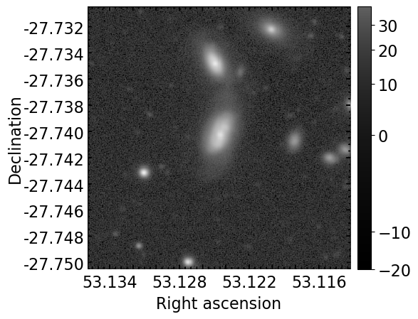

```python
display = afwDisplay.Display()
display.scale('asinh', 'zscale')
display.image(cutout)
plt.show()
```

> **Figure 1:** The cutout image, displayed using LSST pipeline tools in grayscale with a scale bar at right.

Future planned options for the Rubin cutout service, including the potential to retrieve other image formats such as jpeg, are listed at the [Rubin Science Platform image cutout implementation strategy document](https://dmtn-208.lsst.io/).

## 4. Bulk image stamps

Bulk image stamps will be a key visualization tool. Below, it is demonstrated how to retrieve many image stamps (and save as png files). Use the target list already used in tutorial notebook 104.5 for bright (V band magnitude < 22) variability selected galaxies hosting active galactic nuclei (AGN) in the ECDFS field from [Boutsia et al. 2009](https://ui.adsabs.harvard.edu/abs/2009A%26A...497...81B/abstract). Define the targets as a dictionary containing the ID, ra, and dec, store it as an astropy table called `ut1`.

```python
targets = [{'id': '3', 'ra': 53.335875, 'dec': -27.819472},
           {'id': '8', 'ra': 53.194833, 'dec': -28.146306},
           {'id': '9', 'ra': 53.411917, 'dec': -27.671222},
           {'id': '11', 'ra': 53.318792, 'dec': -27.844306},
           {'id': '12', 'ra': 53.191458, 'dec': -27.962583},
           {'id': '14', 'ra': 53.133333, 'dec': -28.052750},
           {'id': '15', 'ra': 52.977708, 'dec': -28.176583},
           {'id': '18', 'ra': 53.380708, 'dec': -27.942833},
           {'id': '20', 'ra': 53.049333, 'dec': -28.153056},
           {'id': '22', 'ra': 53.370542, 'dec': -27.944750},
           {'id': '24', 'ra': 53.290458, 'dec': -27.937222},
           {'id': '25', 'ra': 52.819542, 'dec': -27.724889},
           {'id': '26', 'ra': 53.144042, 'dec': -28.053889},
           {'id': '28', 'ra': 53.337875, 'dec': -27.653278},
           {'id': '29', 'ra': 53.155375, 'dec': -28.146389},
           {'id': '30', 'ra': 53.302625, 'dec': -27.931000},
           {'id': '31', 'ra': 52.797417, 'dec': -27.692194},
           {'id': '32', 'ra': 53.344958, 'dec': -27.923278},
           {'id': '33', 'ra': 53.224583, 'dec': -27.898361},
           {'id': '34', 'ra': 53.359333, 'dec': -27.974917},
           {'id': '35', 'ra': 53.084583, 'dec': -28.037444},
           {'id': '36', 'ra': 53.132417, 'dec': -28.119556},
           {'id': '37', 'ra': 53.371750, 'dec': -27.990750},
           {'id': '39', 'ra': 53.184083, 'dec': -28.174583},
           {'id': '41', 'ra': 52.992208, 'dec': -28.044861},
           {'id': '43', 'ra': 53.333375, 'dec': -27.986778},
           {'id': '44', 'ra': 52.812667, 'dec': -27.921833}]

ut1 = Table(targets)
```

Loop over the targets, use the SIA client to identify the datalink of the relevant `deep_coadd`, and use the `get_cutout` function defined in section 1 to generate the cutout. Then use `imshow` to internally display the image so it can be written to disk as a png file.

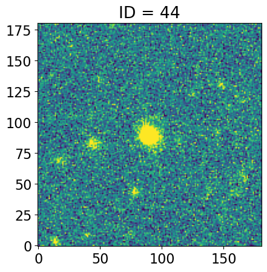

```python
for i in range(len(ut1['id'])):
    plt.title("ID = " + ut1['id'][i])
    cutout_ra = ut1['ra'][i]
    cutout_dec = ut1['dec'][i]

    circle = (cutout_ra, cutout_dec, 0.001)
    eff_wl = 622.1e-09
    results_sci = sia_client.search(pos=circle, calib_level=3,
                                    dpsubtype='lsst.deep_coadd',band=eff_wl)

    results_sci.to_table()
    dl_result = discovery.get_datalink_results(results_sci[0])
    f"Datalink status: {dl_result.status}."

    cutout = get_cutout(dl_result, cutout_ra, cutout_dec, get_pyvo_auth(), 0.01)

    plt.imshow(cutout.array, origin='lower', vmin=np.nanpercentile(cutout.array, 1),
               vmax=np.nanpercentile(cutout.array, 99))

    figname = os.path.join(tempdir, 'stamp_' + str(i) + '.png')
    if os.path.isfile(figname):
        os.remove(figname)
    plt.savefig(figname)
```

> **Figure 2**: The last image stamp generated from the loop that was written to disk as a png file.

Define a function to organize the display with matplotlib of bulk image stamps.

```python
def make_subplot_grid(n_subplots, figsize_per_plot=(4, 3)):
    """
    Create an optimal grid of matplotlib subplots.

    Parameters
    ----------
    n_subplots : int
        The total number of subplots required.
    figsize_per_plot : tuple of float or int, optional
        The (width, height) in inches for each individual subplot.
        The total figure size is scaled automatically based on this
        and the calculated grid size. Default is (4, 3).

    Returns
    -------
    fig : matplotlib.figure.Figure
        The generated matplotlib figure object.
    axes : numpy.ndarray of matplotlib.axes.Axes
        A flattened, 1D array of exactly `n_subplots` axes objects,
        ready for plotting.
    """
    n_cols = np.ceil(np.sqrt(n_subplots)).astype(int)
    n_rows = np.ceil(n_subplots / n_cols).astype(int)

    figsize = (figsize_per_plot[0] * n_cols,
               figsize_per_plot[1] * n_rows)
    fig, axes = plt.subplots(
        n_rows,
        n_cols,
        figsize=figsize,
        gridspec_kw={
            "wspace": 0,
            "hspace": 0})

    axes = axes.flatten()

    for ax in axes:
        ax.axis("off")

    for ax in axes[n_subplots:]:
        ax.remove()

    return fig, axes[:n_subplots]
```

Below, visualize the bulk image stamps that were saved to disk.

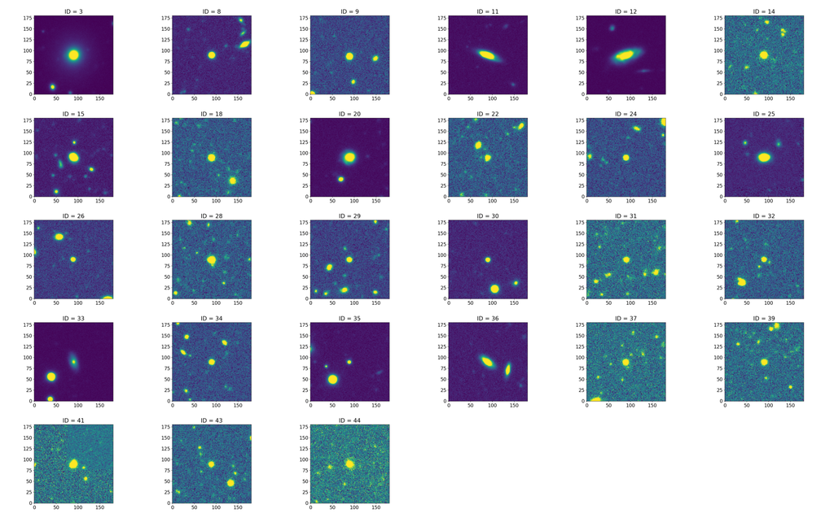

```python
fig, axes = make_subplot_grid(len(targets))
for i, ax in enumerate(axes):

    j = i
    figname = os.path.join(tempdir, 'stamp_' + str(j) + '.png')
    img = mpimg.imread(figname)

    ax.imshow(img)

plt.tight_layout()
plt.show()
```

> **Figure 3**: Image stamps generated from the `deep_coadd` images of each target.